# Democracy Around the World: A Data Analysis

```r
library(tidyverse)
library(purrr)
library(countrycode)
library(ggridges)
library(scales)
library(gt)
library(ggtext)
library(forcats)
```

```r
democracy_data <- readr::read_csv(
  'https://raw.githubusercontent.com/rfordatascience/tidytuesday/main/data/2024/2024-11-05/democracy_data.csv'
)
masterSet <- read.csv("masterSet.csv")
```

# 1 Introduction

Countries do not just become democracies or dictatorships overnight nor do their economic systems alter in this way. Political systems shift, collapse, recover, and sometimes cycle through the same kinds of instability. Some countries remain politically steady for decades, while others seem to rewrite the rules of government every few years. Some countries hold great economic power but others live in poverty. We wanted to know whether these systems follow a pattern in the way regime types change and how that relates to political instability.

For this study, we used data from the Boix-Miller-Rosato Dichotomous Coding of Democracy dataset, which was shared through the TidyTuesday project on GitHub. The dataset provides a detailed look at political systems around the world from 1950 through 2022. Because each row represents a single country in a single year, the data allow us to examine political patterns and changes across more than seven decades of global history.

The dataset was created and curated by political scientists using historical records, expert coding, government documents, and electoral information. Its main purpose is to support research on topics such as democratization, regime stability, election integrity, suffrage, and political representation. This makes it especially useful for studying how democratic and non-democratic systems differ, as well as how political institutions evolve over time. Some of the most important variables include government type, democracy status, full suffrage, postponed elections, female political leadership, and electoral system type. These variables give us a broad view of each country’s political structure and make it possible to compare trends across countries, regions, and years.

## 1.1 Supplemental GDP and Unemployment Data

To look at factors connected to a country’s economic performance, we looked to obtain additional sources for our study. These sources were collected using the API-Ninjas public API and gave us information about GDP, GDP growth, and unemployment. Adding these economic variables helps connect the political side of the project to economic outcomes, which matters because our interests focus on how regime type and leadership may relate to a country’s overall performance.

Our first addition, focuses on national economic output. It came from the API-Ninjas GDP endpoint, which provides country-level economic information from sources such as the World Bank and IMF. Each observation represents one country in one year, so the main unit of analysis is country-year. This source includes variables such as country code, year, nominal GDP, and GDP growth rate. The years available are not the same for every country, but many countries have records across several decades and into the 2020s. We collected this information by using the country codes from our democracy records, sending those country codes through the API, and combining the returned results into one table. This addition is useful because GDP and GDP growth give us a way to compare economic performance across political systems.

The second addition focuses on unemployment. It came from the API-Ninjas unemployment endpoint. Like the GDP source, each observation represents one country in one year, so the unit of analysis is also country-year. This source includes variables such as country code, year, and unemployment rate. The available years differ by country because the API does not return the same amount of information for every country. We collected this information using the same general process as before: we looped through the country codes from our democracy records, requested unemployment information for each country, and combined the results into one table. This source matters because unemployment gives another way to measure economic conditions beyond just national output.

# 2 Areas of Interest

> **Question 2 (Supplemental Data):** What key factors including democracy status, unemployment rate, and female leadership are associated with a country’s GDP?

This question leverages the joined master dataset combining democracy, GDP, and unemployment data, allowing us to model and visualize economic outcomes as a function of political and social variables.

# 3 A Wide Look at Regime Changes Over Time

We were interested in how have regime types changed over time across different continents, and which countries have experienced the most political instability.

## 3.1 Countries with the Most Regime Changes

To investigate our interests we decided to count regime changes between the years 1950 to 2022 for each of the countries and use this as a metric of the stability, where countries who have higher amounts if regime changes would be more unstable. We reported the top ten we found to have the highest regime changes and therefore the highest instability in the plot below. We decided to color the bars with respect to their continents to show further information.

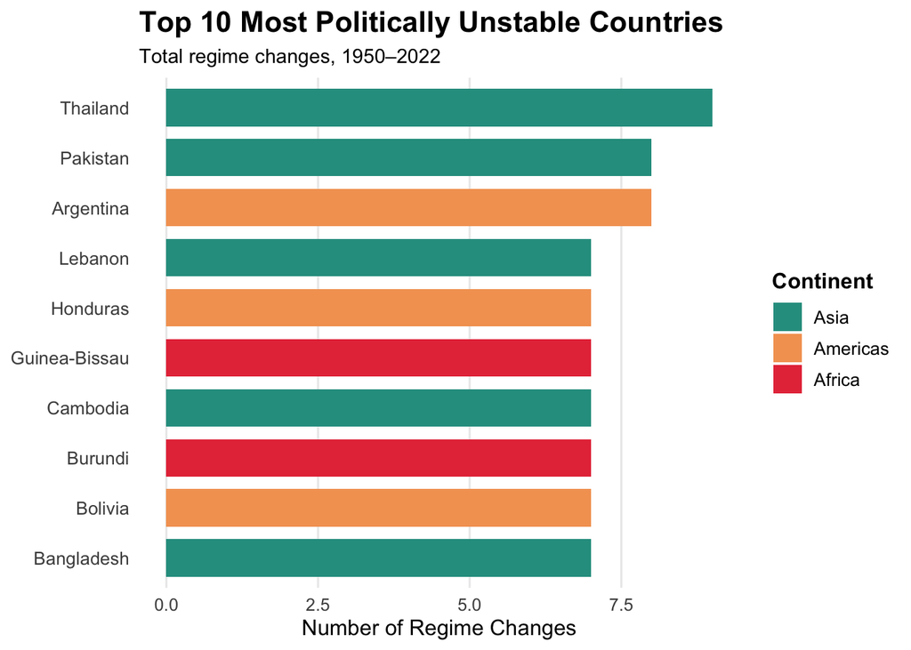

```r
count_regime_changes <- function(country) {
  country_data <- democracy_data |>
    filter(country_name == country) |>
    arrange(year)

  regime <- country_data$regime_category_index
  changes <- regime != lag(regime)
  sum(changes, na.rm = TRUE)
}
continent_cols <- c(
  "Africa" = "#E63946",
  "Americas" = "#F4A261",
  "Asia" = "#2A9D8F",
  "Europe" = "#457B9D",
  "Oceania" = "#9B5DE5"
)
regime_by_country <- democracy_data |>
  arrange(country_name, year) |>
  group_by(country_name) |>
  summarise(
    n_changes = sum(regime_category_index != lag(regime_category_index), na.rm = TRUE),
    .groups = "drop"
  )

top_regime <- regime_by_country |>
  slice_max(n_changes, n = 10, with_ties = FALSE) |>
  mutate(
    continent = countrycode(country_name, "country.name", "continent")
  )

results <- democracy_data |>
  distinct(country_name) |>
  mutate(n_changes = map_dbl(country_name, count_regime_changes))

top_regime_plot <- top_regime |>
  arrange(desc(n_changes)) |>
  mutate(
    country_name = fct_reorder(country_name, n_changes),
    continent = factor(continent, levels = unique(continent))
  )

top_regime_plot |>
  ggplot(aes(
    x = n_changes,
    y = country_name,
    fill = continent
  )) +
  geom_col(width = 0.75) +
  scale_fill_manual(
    values = continent_cols,
    breaks = levels(top_regime_plot$continent),
    na.value = "gray70"
  ) +
  labs(
    title = "Top 10 Most Politically Unstable Countries",
    subtitle = "Total regime changes, 1950–2022",
    x = "Number of Regime Changes",
    y = NULL,
    fill = "Continent"
  ) +
  theme_minimal(base_size = 12) +
  theme(
    legend.position = "right",
    legend.title = element_text(face = "bold"),
    legend.text = element_text(size = 10),
    plot.title = element_text(face = "bold", size = 16),
    plot.subtitle = element_text(size = 11),
    axis.text.y = element_text(size = 10),
    panel.grid.major.y = element_blank(),
    panel.grid.minor = element_blank()
  )
```

From this plot it is apparent that Thailand, Argentina and Pakistan appeared to have the highest number of regime changes across this time period. We notice the top two countries with the highest regime changes are both in Asia. The countries below still showed signed of extreme instability all of which boasting 7 regime changes.

## 3.2 Regime Change Counts by Continent

Zooming out from our country perspective we were interested in a larger frame to pick up on some more general ideas about what is going on around the world in regard to political stability. The table below investigates the number regime changes for each continent and reports the most unstable country within that continent. Since each continent holds a different number of countries we thought it was a good idea to include the average number of changes per country on each given continent.

```r
democracy_data |>
  arrange(country_name, year) |>
  group_by(country_name) |>
  mutate(regime_changed = regime_category_index != lag(regime_category_index)) |>
  ungroup() |>
  mutate(continent = countrycode::countrycode(
    country_name,
    origin = "country.name",
    destination = "continent"
  )) |>
  filter(!is.na(continent)) |>
  group_by(continent, country_name) |>
  summarise(country_changes = sum(regime_changed, na.rm = TRUE), .groups = "drop") |>
  group_by(continent) |>
  summarise(
    `Number of Countries` = n(),
    `Total Regime Changes` = sum(country_changes),
    `Average Changes per Country` = round(mean(country_changes), 2),
    `Most Unstable Country` = country_name[which.max(country_changes)],
    `Max Changes (single country)` = max(country_changes),
    .groups = "drop"
  ) |>
  arrange(desc(`Total Regime Changes`)) |>
  rename(Continent = continent) |>
  gt() |>
  tab_header(
    title = "Regime Change Counts by Continent",
    subtitle = "1950–2022"
  ) |>
  tab_caption("Table 2. Regime change counts by continent, including total changes, average per country, and the most politically unstable country in each region.") |>
  fmt_number(columns = `Average Changes per Country`, decimals = 2) |>
  tab_style(
    style = list(cell_fill(color = "#18bc9c"), cell_text(color = "white", weight = "bold")),
    locations = cells_column_labels()
  ) |>
  tab_style(
    style = cell_text(weight = "bold"),
    locations = cells_body(columns = Continent)
  ) |>
  opt_stylize(style = 1)
```

Table 2. Regime change counts by continent, including total changes, average per country, and the most politically unstable country in each region.

Regime Change Counts by Continent

1950–2022

| Continent | Number of Countries | Total Regime Changes | Average Changes per Country | Most Unstable Country | Max Changes (single country) |
| --- | --- | --- | --- | --- | --- |
| Africa | 54 | 129 | 2.39 | Burundi | 7 |
| Asia | 50 | 95 | 1.90 | Thailand | 9 |
| Americas | 45 | 93 | 2.07 | Argentina | 8 |
| Europe | 42 | 25 | 0.60 | Albania | 4 |
| Oceania | 17 | 6 | 0.35 | Fiji | 5 |

This table gives us a wealth of information. The key things to notice is that Africa has the highest average regime changes per country and therefore has the least stable governments. We also notice that Europe and Oceana have much lower average regime changes per country. Even though Asia contained the countries with two highest amount of regime changes their had less average changes per country than both Africa and the Americas.

## 3.3 Cumulative Regime Changes per Continent Over Time

Sure Africa had the highest number of regime changes over the full span of our data but that doesn’t give us the full story. We wanted to create a visual that allows us to investigate how these continents regime change counts changed over time. Below is our visual showing the cumulative Regime changes over time for each continent.

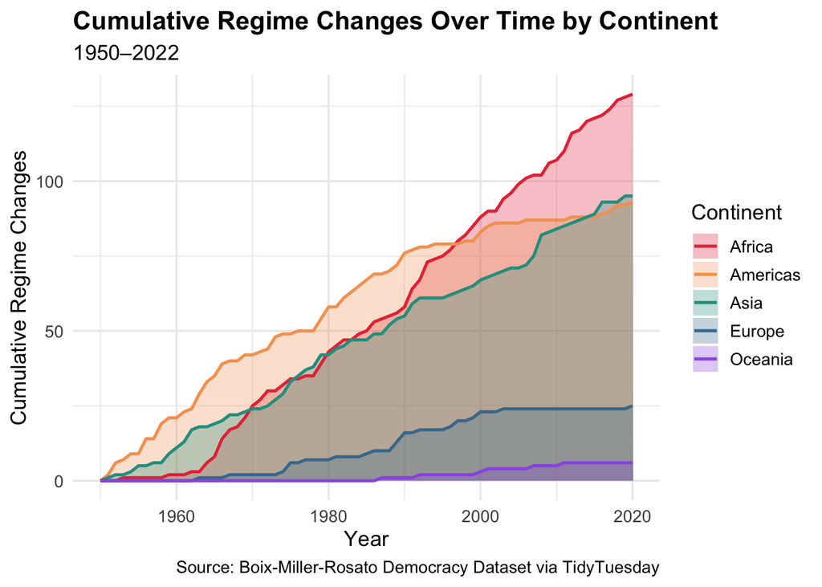

```r
regime_change_counts <- democracy_data |>
  arrange(country_name, year) |>
  group_by(country_name) |>
  mutate(regime_changed = regime_category_index != lag(regime_category_index)) |>
  ungroup() |>
  mutate(continent = countrycode::countrycode(
    country_name,
    origin = "country.name",
    destination = "continent"
  )) |>
  group_by(continent, year) |>
  summarise(n_changes = sum(regime_changed, na.rm = TRUE), .groups = "drop") |>
  group_by(continent) |>
  mutate(cumulative_changes = cumsum(n_changes)) |>
  ungroup()

ggplot(regime_change_counts,
       aes(x = year, y = cumulative_changes, fill = continent)) +
  geom_area(alpha = 0.3, position = "identity") +
  geom_line(aes(color = continent), linewidth = 0.9) +
  scale_color_manual(values = c(
    "Africa"   = "#E63946",
    "Americas" = "#F4A261",
    "Asia"     = "#2A9D8F",
    "Europe"   = "#457B9D",
    "Oceania"  = "#9B5DE5"
  )) +
  scale_fill_manual(values = c(
    "Africa"   = "#E63946",
    "Americas" = "#F4A261",
    "Asia"     = "#2A9D8F",
    "Europe"   = "#457B9D",
    "Oceania"  = "#9B5DE5"
  )) +
  labs(
    x = "Year",
    y = "Cumulative Regime Changes",
    title = "Cumulative Regime Changes Over Time by Continent",
    subtitle = "1950–2022",
    color = "Continent",
    fill = "Continent",
    caption = "Source: Boix-Miller-Rosato Democracy Dataset via TidyTuesday"
  ) +
  theme_minimal(base_size = 13) +
  theme(
    plot.title = element_text(face = "bold"),
    legend.position = "right"
  )
```

This visual shows that Africa did not always have the highest number of regime changes and it only spiked above the rest in the late twentieth century. Asia appears to have a very constant increase in the number of regime changes while it appears the Americas are starting to taper off.

# 4 Democracy, Unemployment, GDP, and Gender

We were interested in how factors like democracy status, unemployment type, GDP, and gender of leadership relate to each other. Political and economic systems are do not exist in fully separate worlds. All of these factors work with each other separate and help give us an idea of how countries function with respect to their leadership and economic status.

## 4.1 Proportion of Years with a Female Leader by Regime Type and Election System

The table below shows the regime categories with the highest proportions of years that included a female leader. It shows where female leadership was more common in the historical record giving us insight on what regime types boasts the most female leaders.

```r
sum_female_leader <- function(democ_data, columns, group) {
  female_leader_any <- democ_data |>
    rowwise() |>
    mutate(female_leader = any(c_across(all_of(columns)), na.rm = TRUE)) |>
    ungroup()

  prop_female <- female_leader_any |>
    group_by(across(all_of(group))) |>
    summarise(prop_female_leader = mean(female_leader, na.rm = TRUE),
              .groups = "drop")

  return(prop_female)
}

# By regime category
sum_female_leader(
  democracy_data,
  columns = c("is_female_monarch", "is_female_president"),
  group = "regime_category"
) |>
  filter(!is.na(regime_category)) |>
  arrange(desc(prop_female_leader)) |>
  slice_head(n = 25) |>
  rename(`Regime Category` = regime_category,
         `Proportion with Female Leader` = prop_female_leader) |>
  gt() |>
  tab_header(
    title = "Female Leadership by Regime Type",
    subtitle = "Top 25 regime categories by proportion of country-years with a female leader"
  ) |>
  tab_caption("Table 3. Top 25 regime categories by proportion of country-years with a female leader.") |>
  fmt_percent(columns = `Proportion with Female Leader`, decimals = 1) |>
  tab_style(
    style = list(cell_fill(color = "#18bc9c"), cell_text(color = "white", weight = "bold")),
    locations = cells_column_labels()
  ) |>
  opt_stylize(style = 1)
```

Table 3. Top 25 regime categories by proportion of country-years with a female leader.

Female Leadership by Regime Type

Top 25 regime categories by proportion of country-years with a female leader

| Regime Category | Proportion with Female Leader |
| --- | --- |
| British Dependent Territory | 100.0% |
| British Overseas Territory | 100.0% |
| Colony (Constituent Country) as the Netherlands Antilles | 100.0% |
| Colony within St. Christopher-Nevis-Anguilla | 100.0% |
| Crown colony | 100.0% |
| Crown colony administered from the Bahamas | 100.0% |
| Direct British control after de facto separation with St. Kitts and Nevis | 100.0% |
| Free association with New Zealand | 100.0% |
| Overseas Territory | 100.0% |
| New Zealand dependent territory | 86.7% |
| Colony administered from St. Kitts | 84.6% |
| British protected state | 80.0% |
| Colony administed from Jamaica | 75.0% |
| Colony administered from Jamaica | 75.0% |
| Constituent Country of the Netherlands | 70.0% |
| Crown Colony | 31.0% |
| Colony within the West Indies Federation | 25.0% |
| Parliamentary democracy | 9.0% |
| Colony | 7.5% |
| Mixed democratic | 6.3% |
| Presidential democracy | 6.0% |
| Civilian dictatorship | 0.6% |
| Military dictatorship | 0.3% |
| Administered by British military | 0.0% |
| British Protectorate | 0.0% |

It is important to not that thew highest proportions of female leader come from the small regime categories that gave only existed with female leaders. Looking closer at the table we notice colonies have a high proportion of female leaders as well.

We wanted to grasp what election systems were most often associated with female leadership. While the first table allowed us to see female leaders by regime type, this second table looks at election systems to see whether certain voting structures appear more frequently in years with female leaders. This helps us compare female leadership across political institutions, rather than only across regime categories.

```r
# By election system
sum_female_leader(
  democracy_data,
  columns = c("is_female_monarch", "is_female_president"),
  group = "election_system"
) |>
  filter(!is.na(election_system)) |>
  arrange(desc(prop_female_leader)) |>
  slice_head(n = 22) |>
  rename(`Election System` = election_system,
         `Proportion with Female Leader` = prop_female_leader) |>
  gt() |>
  tab_header(
    title = "Female Leadership by Election System",
    subtitle = "Proportion of country-years with a female leader"
  ) |>
  tab_caption("Table 4. Proportion of country-years with a female leader by election system.") |>
  fmt_percent(columns = `Proportion with Female Leader`, decimals = 1) |>
  tab_style(
    style = list(cell_fill(color = "#18bc9c"), cell_text(color = "white", weight = "bold")),
    locations = cells_column_labels()
  ) |>
  opt_stylize(style = 1)
```

Table 4. Proportion of country-years with a female leader by election system.

Female Leadership by Election System

Proportion of country-years with a female leader

| Election System | Proportion with Female Leader |
| --- | --- |
| FPTP and proportional | 100.0% |
| Proportional representation | 100.0% |
| Selected by committee | 100.0% |
| Hagenbasch-Bischoff | 91.2% |
| d'Hondt and Saint algue | 73.1% |
| Multiple vote | 47.7% |
| Mixed PR / FPTP | 41.7% |
| Mix PR and functional constituencies | 32.4% |
| PR | 30.3% |
| STV | 21.8% |
| List PR (large multi-member) | 12.9% |
| FPTP and d'Hondt | 10.0% |
| FPTP and appointed | 9.7% |
| FPTP / Bloc voting | 9.3% |
| MMP / FPTP | 9.1% |
| FPTP | 8.9% |
| List PR | 6.1% |
| Mixed member SMD/PR | 5.5% |
| Parallel SMD/PR | 5.5% |
| List PR (small multi-member) | 4.8% |
| Bloc voting | 2.7% |
| 346 elected by municipal citizens, 181 chosen by 'social sectors' | 0.0% |

This table shows that female leadership appears more often in some election systems than others. Several systems, such as FPTP and proportional representation, proportional representation, and selection by committee, show the highest proportions of country-years with female leaders. However, some of these categories may have fewer total observations similar to our regime table, so the percentages should be examined carefully. Overall, the table suggests that female leadership is not evenly spread across election systems and may be more common under election systems that use a small group to pick a leader.

## 4.2 GDP Growth Distribution by Female Leadership Status (2015–2020)

Now that we have been able to look at where female leadership appears most frequently across election systems and regime types, we wanted to see whether female leadership is connected to economic outcomes. To do this, we looked at GDP growth from 2015 to 2020 and compared years with a female leader to years without a female leader. This visual helps us move beyond simply counting female leaders and instead asks whether countries with female leaders show different patterns of economic growth.

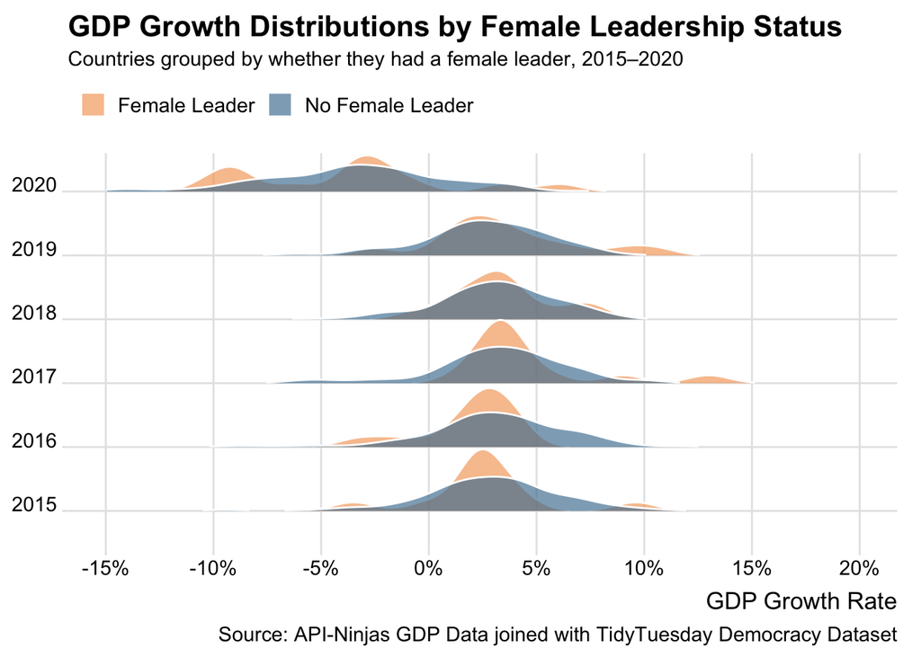

```r
female_leader_any <- masterSet |>
  rowwise() |>
  mutate(
    female_leader = any(
      c_across(c(is_female_monarch, is_female_president)) == 1,
      na.rm = TRUE
    )
  ) |>
  ungroup() |>
  filter(!is.na(gdp_growth))

female_leader_any |>
  filter(year > 2014) |>
  mutate(
    female_leader = if_else(female_leader, "Female Leader", "No Female Leader"),
    year = factor(year)
  ) |>
  ggplot(aes(x = gdp_growth, y = year, fill = female_leader)) +
  geom_density_ridges(
    alpha = 0.65,
    color = "white",
    scale = 0.99,
    rel_min_height = 0.01
  ) +
  scale_x_continuous(
    limits = c(-15, 20),
    breaks = seq(-15, 20, 5),
    labels = label_number(suffix = "%")
  ) +
  scale_fill_manual(values = c(
    "No Female Leader" = "#457B9D",
    "Female Leader"    = "#F4A261"
  )) +
  labs(
    title = "GDP Growth Distributions by Female Leadership Status",
    subtitle = "Countries grouped by whether they had a female leader, 2015–2020",
    x = "GDP Growth Rate",
    y = NULL,
    fill = NULL,
    caption = "Source: API-Ninjas GDP Data joined with TidyTuesday Democracy Dataset"
  ) +
  theme_ridges(font_size = 13, grid = TRUE) +
  theme(
    legend.position = "top",
    legend.justification = "left",
    plot.title = element_text(face = "bold", size = 16)
  )
```

The ridge plot shows that countries with and without female leaders had fairly similar GDP growth distributions from 2015 to 2020. Most years show slight positive growth. In some cases GDP growth with female leaders appears on the right tail indicating female leadership can be associated with slightly higher levels of GDP growth. However it is very slight so we cannot say there is a clear separation. This plot also highlights the negative growth that was globally experienced in 2020 likely due to COVID-19.

#### 4.2.0.1 GDP Growth: Democracies vs. Non-Democracies Over Time

Continuing our analysis of GDP we want to compare economic performance more directly across political systems. The graph below shows average GDP growth for democracies and non-democracies over time. This helps us see whether one group consistently experienced stronger growth, or whether both groups followed similar global economic patterns.

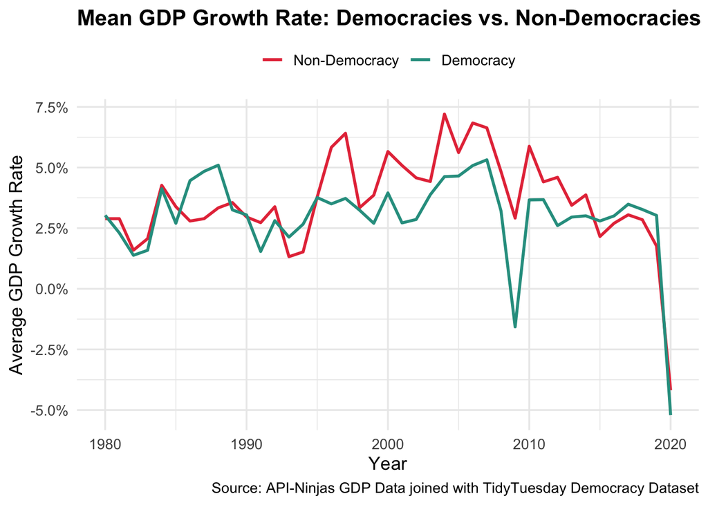

```r
aveGrowth <- masterSet |>
  group_by(year, is_democracy) |>
  summarise(mean_growth = mean(gdp_growth, na.rm = TRUE), .groups = "drop") |>
  filter(!is.na(mean_growth), !is.na(is_democracy))

ggplot(aveGrowth, aes(x = year, y = mean_growth, color = factor(is_democracy))) +
  geom_line(linewidth = 1) +
  scale_color_manual(
    values = c("FALSE" = "#E63946", "TRUE" = "#2A9D8F"),
    labels = c("FALSE" = "Non-Democracy", "TRUE" = "Democracy")
  ) +
  scale_y_continuous(labels = label_number(suffix = "%")) +
  labs(
    x = "Year",
    y = "Average GDP Growth Rate",
    title = "Mean GDP Growth Rate: Democracies vs. Non-Democracies",
    color = NULL,
    caption = "Source: API-Ninjas GDP Data joined with TidyTuesday Democracy Dataset"
  ) +
  theme_minimal(base_size = 13) +
  theme(
    plot.title = element_text(face = "bold"),
    legend.position = "top"
  )
```

The graph shows that democracies and non-democracies follow fairly similar GDP growth patterns over time, with both groups experiencing rises and drops. Non-democracies appear to have slightly higher average growth in several years, especially in the late 1990s and early 2000s, but the two lines often move in the same direction. Again we are able to see the negative growth that was globally experienced in 2020 likely due to COVID-19

# 5 Predicting GDP Based on Political & Economic Factors

We used a linear regression model to examine how economic and political factors are associated with a country’s GDP. The response variable in the model was the log of nominal GDP, while the predictor variables included year, unemployment rate, democratic status, and an interaction between unemployment rate and democratic status. Including year allowed us to account for overall economic growth over time, while unemployment rate served as an economic indicator that may help explain differences in GDP. Democratic status was included to test whether democracies and non-democracies tend to differ in GDP, and the interaction term allowed us to examine whether the relationship between unemployment and GDP changes depending on whether a country is democratic. We used the log of GDP because nominal GDP is highly right-skewed, meaning that a small number of countries have extremely large GDP values compared to the rest of the dataset. Taking the log helps reduce this skew, stabilize the variation in the data, and make the model coefficients easier to interpret. We also excluded the year 2020 from the model because the COVID-19 pandemic created unusual economic disruptions that could distort the overall relationship between GDP, unemployment, and democracy.

```r
mastfilt <- masterSet |>
  dplyr::filter(
    !is.na(gdp_nominal),
    !is.na(unemployment_rate),
    !is.na(year),
    !is.na(is_democracy),
    year != 2020
  )
```

```r
lmGDP <- lm(log(gdp_nominal) ~ unemployment_rate * is_democracy + year,
            data = mastfilt)
```

```r
broom::tidy(lmGDP) |>
  mutate(
    term = case_when(
      term == "(Intercept)"                        ~ "Intercept",
      term == "unemployment_rate"                  ~ "Unemployment Rate",
      term == "is_democracyTRUE"                   ~ "Is Democracy",
      term == "year"                               ~ "Year",
      term == "unemployment_rate:is_democracyTRUE" ~ "Unemployment × Democracy"
    ),
    across(c(estimate, std.error, statistic), ~ round(.x, 4)),
    p.value = case_when(
      p.value < 0.001 ~ "< 0.001",
      TRUE ~ as.character(round(p.value, 3))
    )
  ) |>
  rename(
    Term = term,
    Estimate = estimate,
    `Std. Error` = std.error,
    `t-statistic` = statistic,
    `p-value` = p.value
  ) |>
  gt() |>
  tab_header(
    title = "Linear Regression: Predictors of Log(Nominal GDP)"
  ) |>
  tab_caption("Table 5. Linear regression model predicting log(Nominal GDP). Coefficients represent the change in log(GDP) for a one-unit increase in each predictor.") |>
  tab_style(
    style = list(cell_fill(color = "#18bc9c"), cell_text(color = "white", weight = "bold")),
    locations = cells_column_labels()
  ) |>
  tab_style(
    style = cell_fill(color = "#f0faf7"),
    locations = cells_body(rows = c(3, 5))
  ) |>
  tab_style(
    style = cell_text(weight = "bold"),
    locations = cells_body(columns = Term)
  ) |>
  opt_stylize(style = 1)
```

Table 5. Linear regression model predicting log(Nominal GDP). Coefficients represent the change in log(GDP) for a one-unit increase in each predictor.

Linear Regression: Predictors of Log(Nominal GDP)

| Term | Estimate | Std. Error | t-statistic | p-value |
| --- | --- | --- | --- | --- |
| Intercept | -77.1608 | 6.2457 | -12.3542 | < 0.001 |
| Unemployment Rate | -0.0305 | 0.0094 | -3.2270 | 0.001 |
| Is Democracy | 1.1213 | 0.1349 | 8.3140 | < 0.001 |
| Year | 0.0406 | 0.0031 | 13.0131 | < 0.001 |
| Unemployment × Democracy | -0.0923 | 0.0120 | -7.6937 | < 0.001 |

**Key findings from the model:**

- **Year** has a significant positive coefficient, confirming that GDP has grown over time on average across all countries, regardless of political regime.
- **Unemployment rate** is negatively associated with log(GDP), as expected — higher unemployment is associated with smaller economies.
- **Is Democracy** is positively associated with log(GDP), suggesting democratic countries tend to have higher GDPs on average.
- The **interaction term** (Unemployment × Democracy) is negative and significant, meaning the negative relationship between unemployment and GDP is *stronger* in democracies than in non-democracies. In other words, rising unemployment is more damaging to GDP in democratic countries.

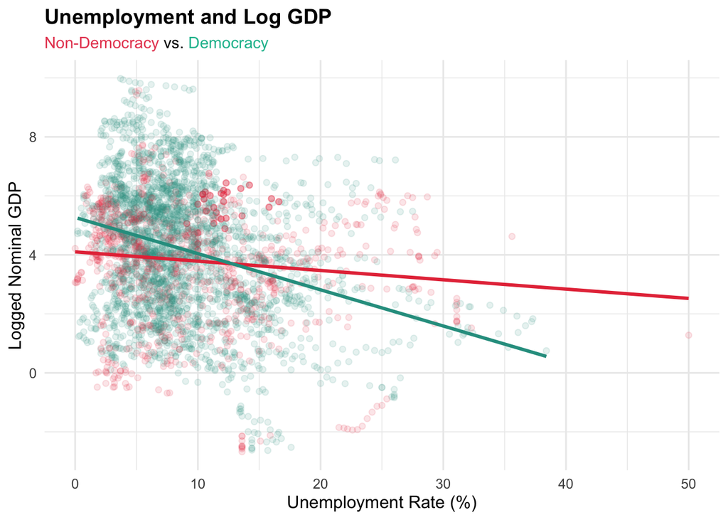

```r
model_data <- masterSet |>
  filter(
    !is.na(gdp_nominal),
    gdp_nominal > 0,
    !is.na(unemployment_rate),
    !is.na(is_democracy),
    !is.na(year),
    year != 2020
  )
democracy_cols <- c(
  "FALSE" = "#E63946",
  "TRUE" = "#2A9D8F"
)

model_data |>
  ggplot(aes(
    x = unemployment_rate,
    y = log(gdp_nominal),
    color = factor(is_democracy)
  )) +
  geom_point(alpha = 0.12) +
  geom_smooth(method = "lm", se = FALSE, linewidth = 1.1) +
  scale_color_manual(
    values = democracy_cols,
    labels = c("FALSE" = "Non-Democracy", "TRUE" = "Democracy")
  ) +
  labs(
    title = "Unemployment and Log GDP",
    subtitle = "<span style='color:#E84A5F; font-weight:bold;'>Non-Democracy</span> vs. <span style='color:#18bc9c; font-weight:bold;'>Democracy</span>",
    x = "Unemployment Rate (%)",
    y = "Logged Nominal GDP",
    color = NULL
  ) +
  theme_minimal(base_size = 12) +
  theme(
    plot.title = element_text(face = "bold"),
    plot.subtitle = ggtext::element_markdown(size = 11),
    legend.position = "none"
  )
```

This plot helps us visualize what the interaction term is really representing. As unemployment increases, logged GDP tends to decrease for both democracies and non-democracies. However, the decline is steeper for democracies, suggesting that unemployment is more strongly related to lower GDP in democratic countries.